# Flights dataset Exploration

## by Ahmed Mohammed Mohammed

## Preliminary Wrangling

> The data set keeps record of the fligths info in the US airports in the period from 2010 to 2020. It contains detailed information about the number of flights delayed, time delayed, reasons for delays and the contribution of each reason. It also keeps record of the canceled and diverted flights in each month for each airport and carrier.

```python
# import all packages and set plots to be embedded inline
import numpy as np
import pandas as pd
import matplotlib.pyplot as plt
import seaborn as sb

%matplotlib inline
```

```python
flight_df = pd.read_csv('FlightDelaying.csv')
flight_df.drop(columns='Unnamed: 21',inplace =True)
flight_df.columns = flight_df.columns.str.replace(' ', '')
print(flight_df.shape)
print(flight_df.dtypes)
print(flight_df.isnull().sum())
```

```
(165586, 21)
year                     int64
month                    int64
carrier                 object
carrier_name            object
airport                 object
airport_name            object
arr_flights            float64
arr_del15              float64
carrier_ct             float64
weather_ct             float64
nas_ct                 float64
security_ct            float64
late_aircraft_ct       float64
arr_cancelled          float64
arr_diverted           float64
arr_delay              float64
carrier_delay          float64
weather_delay          float64
nas_delay              float64
security_delay         float64
late_aircraft_delay    float64
dtype: object
year                     0
month                    0
carrier                  0
carrier_name             0
airport                  0
airport_name             0
arr_flights            201
arr_del15              396
carrier_ct             201
weather_ct             201
nas_ct                 201
security_ct            201
late_aircraft_ct       201
arr_cancelled          201
arr_diverted           201
arr_delay              201
carrier_delay          201
weather_delay          201
nas_delay              201
security_delay         201
late_aircraft_delay    201
dtype: int64
```

## Remove the null records

```python
flight_df.dropna(inplace=True)
print(flight_df.isnull().sum().sum())
print(flight_df.shape)
```

```
0
(165190, 21)
```

```python
flight_df.head()
```

|  | year | month | carrier | carrier_name | airport | airport_name | arr_flights | arr_del15 | carrier_ct | weather_ct | ... | security_ct | late_aircraft_ct | arr_cancelled | arr_diverted | arr_delay | carrier_delay | weather_delay | nas_delay | security_delay | late_aircraft_delay |
| --- | --- | --- | --- | --- | --- | --- | --- | --- | --- | --- | --- | --- | --- | --- | --- | --- | --- | --- | --- | --- | --- |
| 0 | 2010 | 1 | 9E | Pinnacle Airlines Inc. | ABE | Allentown/Bethlehem/Easton, PA: Lehigh Valley ... | 65.0 | 16.0 | 5.44 | 0.00 | ... | 0.0 | 0.00 | 1.0 | 0.0 | 765.0 | 440.0 | 0.0 | 325.0 | 0.0 | 0.0 |
| 1 | 2010 | 1 | 9E | Pinnacle Airlines Inc. | AEX | Alexandria, LA: Alexandria International | 60.0 | 17.0 | 4.81 | 0.49 | ... | 0.0 | 3.81 | 4.0 | 0.0 | 1029.0 | 297.0 | 99.0 | 335.0 | 0.0 | 298.0 |
| 2 | 2010 | 1 | 9E | Pinnacle Airlines Inc. | ALB | Albany, NY: Albany International | 81.0 | 34.0 | 9.73 | 1.42 | ... | 0.0 | 3.28 | 1.0 | 1.0 | 1535.0 | 533.0 | 77.0 | 700.0 | 0.0 | 225.0 |
| 3 | 2010 | 1 | 9E | Pinnacle Airlines Inc. | ALO | Waterloo, IA: Waterloo Regional | 3.0 | 1.0 | 0.00 | 0.00 | ... | 0.0 | 0.00 | 0.0 | 0.0 | 16.0 | 0.0 | 0.0 | 16.0 | 0.0 | 0.0 |
| 4 | 2010 | 1 | 9E | Pinnacle Airlines Inc. | ATL | Atlanta, GA: Hartsfield-Jackson Atlanta Intern... | 1067.0 | 271.0 | 42.76 | 9.40 | ... | 0.0 | 62.78 | 46.0 | 4.0 | 15932.0 | 4225.0 | 1098.0 | 6092.0 | 0.0 | 4517.0 |

5 rows × 21 columns

```python
flight_df.duplicated().sum()
```

```
0
```

### What is the structure of your dataset?

> The data set contains 21 columns and 165190 rows. It records the year,month ,airports names and codes, carriers names and codes. For each flight described by the previous features the number of flights is recorded in each month (arr_flights).The number of flghts delayed by more than 15 minutes (arr_delay15) is recorded in each month and the contribution of the different factors in the number of delayed flights, and time of delation in minutes are recorded. The factors are severe weather conditions, carrier problems, security, late aircraft (aircrafts that have a flight right after another flight) or National Air System delays (NAS).

### What is/are the main feature(s) of interest in your dataset?

> The airports and carriers performance across years and months in each year.

### What features in the dataset do you think will help support your investigation into your feature(s) of interest?

> I think that the number of flights cancelled, diverted, delayed across the months will be the major important features. Also the delation time that is independent of weather and NAS delays (airport and carriers delays) will be important too.

## Univariate Exploration

> > On each record in the data set is uniquely identified with month, year, airport and a carrier. Firstly I explore the years and months records which reflects the variety of carriers associated with airports in time.

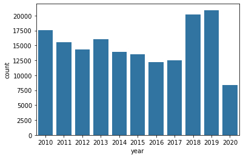

```python
color = sb.color_palette()[0]
sb.countplot(data = flight_df,x='year',color=color);
```

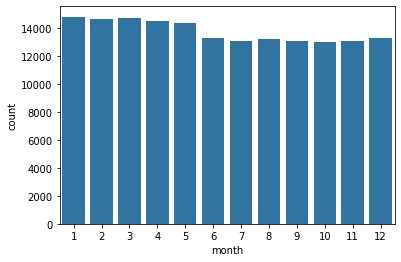

```python
sb.countplot(data = flight_df,x='month',color=color);
```

> The records in each year looks to be in range from 12500 (2016) to more than 20000 (2019) except for 2020 as the data contains records until may 2020 only.The records number in different months is almost the same with slight increase in months from 1 to 5 which corresponds to the 2020 records.

Now let's see carriers and airports records

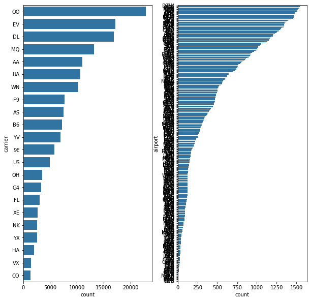

```python
plt.figure(figsize = (10,10))
plt.subplot(1,2,1)
sb.countplot(data = flight_df,y='carrier',color=color,order = flight_df['carrier'].value_counts().index);
plt.subplot(1,2,2)
sb.countplot(data = flight_df,y='airport',color=color,order = flight_df['airport'].value_counts().index);
```

```python
print(flight_df['carrier'].nunique())
flight_df['airport'].nunique()
```

```
22
```

```
386
```

> The carriers records varry from the OO carrier which appears to have a lot of records (20000) to the CO carrier which appears to have a small number of records (1000). For the airports, it looks like we have a lot of airports with each of 1500 record or less.

```python
print(flight_df['airport'].value_counts())
flight_df['airport'].value_counts().nunique()
```

```
DTW    1553
DCA    1546
ATL    1545
MSY    1540
LAX    1536
       ...
DEC       3
FNL       1
TUP       1
CDB       1
YNG       1
Name: airport, Length: 386, dtype: int64
```

```
281
```

> This suggests that there are some airports on the data set number of records identical to other airports.

```python
#arr_flights,arr_del15,arr_cancelled
flight_df.columns
```

```
Index(['year', 'month', 'carrier', 'carrier_name', 'airport', 'airport_name',
       'arr_flights', 'arr_del15', 'carrier_ct', 'weather_ct', 'nas_ct',
       'security_ct', 'late_aircraft_ct', 'arr_cancelled', 'arr_diverted',
       'arr_delay', 'carrier_delay', 'weather_delay', 'nas_delay',
       'security_delay', 'late_aircraft_delay'],
      dtype='object')
```

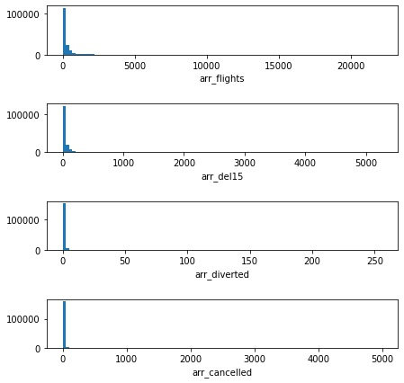

```python
number_of_flights = ['arr_flights','arr_del15','arr_diverted','arr_cancelled']
fig,ax = plt.subplots(nrows=4,figsize=(7,7),gridspec_kw={'hspace':1})
for i,n in enumerate(number_of_flights):
    step = (flight_df[n].max() - flight_df[n].min())/100
    nbins = np.arange(0,flight_df[n].max()+step,step)
    ax[i].hist(data = flight_df,x=n,bins=nbins)
    ax[i].set_xlabel(n)
```

> There are very large outler in each let's plot on log scale

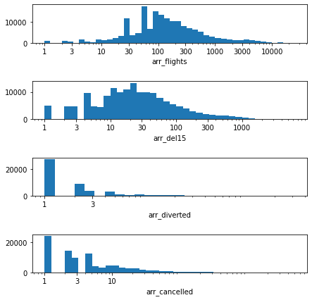

```python
number_of_flights = ['arr_flights','arr_del15','arr_diverted','arr_cancelled']
fig,ax = plt.subplots(nrows=4,figsize=(7,7),gridspec_kw={'hspace':1})
xlims = [30000,3000,10,30]
labels = [1,3,10,30,100,300,1000,3000,10000,30000]
for i,n in enumerate(number_of_flights):
    step = 0.1
    nbins = 10**np.arange(0,np.log10(flight_df[n].max())+step,step)
    ax[i].hist(data = flight_df,x=n,bins=nbins)
    ax[i].set_xlabel(n)
    ax[i].set_xscale('log')
    ind =labels.index(xlims[i])
    #print(ind)
    ax[i].set_xticks(labels[:ind])
    ax[i].set_xticklabels(labels[:ind])
```

> The arrived flights looks to have a left skewed distribution with approximately 100 flights mean. The number of delay flights is right skewed. For the cancelation and divertion there looks to be a small number of values with high number of values. If we summed all the numbers we get the whole number of flights requested which supposed to be normally ditributed.

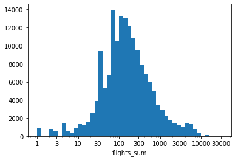

```python
step = 0.1
flight_df['flights_sum'] = flight_df[['arr_flights','arr_del15','arr_diverted','arr_cancelled']].sum(axis=1)
n = 'flights_sum'
nbins = 10**np.arange(0,np.log10(flight_df[n].max())+step,step)
plt.hist(data = flight_df,x=n,bins=nbins)
plt.xlabel(n)
plt.xscale('log')
ind =labels.index(xlims[i])
#print(ind)
plt.xticks(labels,labels);
```

> as expected the whole number of flights is normally distributed (with some high peaks).

> The cancelled flights and the diverted flights looks to have high outliers

```python
print(flight_df['arr_cancelled'].value_counts().sort_index())
print(flight_df['arr_diverted'].value_counts().sort_index())
```

```
0.0       68736
1.0       24370
2.0       14757
3.0        9870
4.0        7139
          ...
2730.0        1
2839.0        1
2945.0        1
3154.0        1
4951.0        1
Name: arr_cancelled, Length: 577, dtype: int64
0.0      116551
1.0       27205
2.0        8828
3.0        3899
4.0        2134
          ...
146.0         1
151.0         1
160.0         1
197.0         1
256.0         1
Name: arr_diverted, Length: 118, dtype: int64
```

```python
flight_df['arr_cancelled'].describe()
```

```
count    165190.000000
mean          7.766772
std          43.897668
min           0.000000
25%           0.000000
50%           1.000000
75%           4.000000
max        4951.000000
Name: arr_cancelled, dtype: float64
```

> The cancelation ad divertion looks to have big outliers that exits in few records.

```python
print(((flight_df['arr_cancelled']>1000)).sum())
print((flight_df['arr_diverted']>100).sum())
print(((flight_df['arr_cancelled']>1000) & (flight_df['arr_diverted']>100)).sum())
```

```
49
29
2
```

```python
flight_df.loc[((flight_df['arr_cancelled']>1000) | (flight_df['arr_diverted']>100)),:].head()
```

|  | year | month | carrier | carrier_name | airport | airport_name | arr_flights | arr_del15 | carrier_ct | weather_ct | ... | late_aircraft_ct | arr_cancelled | arr_diverted | arr_delay | carrier_delay | weather_delay | nas_delay | security_delay | late_aircraft_delay | flights_sum |
| --- | --- | --- | --- | --- | --- | --- | --- | --- | --- | --- | --- | --- | --- | --- | --- | --- | --- | --- | --- | --- | --- |
| 5873 | 2010 | 5 | AA | American Airlines Inc. | DFW | Dallas/Fort Worth, TX: Dallas/Fort Worth Inter... | 13015.0 | 2284.0 | 486.80 | 168.47 | ... | 784.84 | 284.0 | 122.0 | 145903.0 | 37863.0 | 13252.0 | 41141.0 | 68.0 | 53579.0 | 15705.0 |
| 10576 | 2012 | 4 | AA | American Airlines Inc. | DFW | Dallas/Fort Worth, TX: Dallas/Fort Worth Inter... | 12738.0 | 1402.0 | 319.90 | 117.12 | ... | 645.97 | 799.0 | 106.0 | 110512.0 | 25680.0 | 9964.0 | 16184.0 | 0.0 | 58684.0 | 15045.0 |
| 14148 | 2012 | 7 | AA | American Airlines Inc. | DFW | Dallas/Fort Worth, TX: Dallas/Fort Worth Inter... | 12996.0 | 2258.0 | 543.53 | 95.42 | ... | 820.02 | 212.0 | 129.0 | 153330.0 | 46954.0 | 8439.0 | 42056.0 | 36.0 | 55845.0 | 15595.0 |
| 15838 | 2014 | 5 | AA | American Airlines Inc. | DFW | Dallas/Fort Worth, TX: Dallas/Fort Worth Inter... | 13409.0 | 2315.0 | 543.34 | 139.68 | ... | 963.68 | 405.0 | 103.0 | 179706.0 | 46024.0 | 20775.0 | 44067.0 | 57.0 | 68783.0 | 16232.0 |
| 18136 | 2014 | 6 | WN | Southwest Airlines Co. | MDW | Chicago, IL: Chicago Midway International | 7125.0 | 1910.0 | 451.29 | 125.16 | ... | 927.07 | 66.0 | 103.0 | 123035.0 | 24335.0 | 15406.0 | 24650.0 | 83.0 | 58561.0 | 9204.0 |

5 rows × 22 columns

> High cancellation and divertion can be caused by serious conditions or as seen in the data unsusually high flights num.

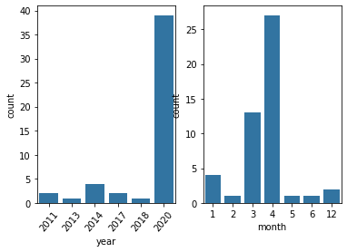

```python
unusual_flights = flight_df.loc[((flight_df['arr_cancelled']>1000)),:]
color = sb.color_palette()[0]
plt.subplot(1,2,1)
sb.countplot(data=unusual_flights,x='year',color=color)
plt.xticks(rotation=50);
plt.subplot(1,2,2)
sb.countplot(data=unusual_flights,x='month',color=color)
```

> as appears the high cancellation is in 2020 mainly due to corona virus. The cancelation is mostly in March and April.

> This data will not help us to know carriers and airpots performance so, we will consider the data until 2019 only.

```python
print((flight_df['arr_diverted']==0).sum())
(flight_df['arr_diverted']>5).sum()
```

```
116551
```

```
5268
```

> This explains the distribution of the divertion. It has 0 value most of the times and a value between 1 and 5 in most of the cases if there are a divertion.

```python
#gets the data before 2020
flight_df = flight_df.query('year<2020')
flight_df.shape[0]
```

```
156861
```

```python
print(((flight_df['arr_cancelled']>1000)).sum())
flight_df.loc[((flight_df['arr_cancelled']>1000)),:].tail()
```

```
10
```

|  | year | month | carrier | carrier_name | airport | airport_name | arr_flights | arr_del15 | carrier_ct | weather_ct | ... | late_aircraft_ct | arr_cancelled | arr_diverted | arr_delay | carrier_delay | weather_delay | nas_delay | security_delay | late_aircraft_delay | flights_sum |
| --- | --- | --- | --- | --- | --- | --- | --- | --- | --- | --- | --- | --- | --- | --- | --- | --- | --- | --- | --- | --- | --- |
| 143342 | 2013 | 12 | AA | American Airlines Inc. | DFW | Dallas/Fort Worth, TX: Dallas/Fort Worth Inter... | 13032.0 | 2524.0 | 506.22 | 107.33 | ... | 1117.43 | 1389.0 | 27.0 | 156609.0 | 46782.0 | 8364.0 | 31441.0 | 36.0 | 69986.0 | 16972.0 |
| 144783 | 2014 | 1 | DL | Delta Air Lines Inc. | ATL | Atlanta, GA: Hartsfield-Jackson Atlanta Intern... | 17071.0 | 4024.0 | 1005.96 | 193.33 | ... | 1427.84 | 1201.0 | 14.0 | 325690.0 | 110997.0 | 22972.0 | 87901.0 | 0.0 | 103820.0 | 22310.0 |
| 144943 | 2014 | 1 | EV | ExpressJet Airlines Inc. | ORD | Chicago, IL: Chicago O'Hare International | 4001.0 | 1192.0 | 212.37 | 22.45 | ... | 485.33 | 1113.0 | 9.0 | 93067.0 | 19551.0 | 2782.0 | 30472.0 | 0.0 | 40262.0 | 6315.0 |
| 145202 | 2014 | 1 | MQ | American Eagle Airlines Inc. | ORD | Chicago, IL: Chicago O'Hare International | 5478.0 | 2091.0 | 327.91 | 91.64 | ... | 789.13 | 1312.0 | 4.0 | 181995.0 | 38974.0 | 8622.0 | 63090.0 | 0.0 | 71309.0 | 8885.0 |
| 145962 | 2014 | 2 | DL | Delta Air Lines Inc. | ATL | Atlanta, GA: Hartsfield-Jackson Atlanta Intern... | 15689.0 | 2435.0 | 611.40 | 120.36 | ... | 812.33 | 1074.0 | 13.0 | 147169.0 | 60608.0 | 12742.0 | 29819.0 | 42.0 | 43958.0 | 19211.0 |

5 rows × 22 columns

> The high cancellation looks to be consistent with the data as there are high number of flights in these records.

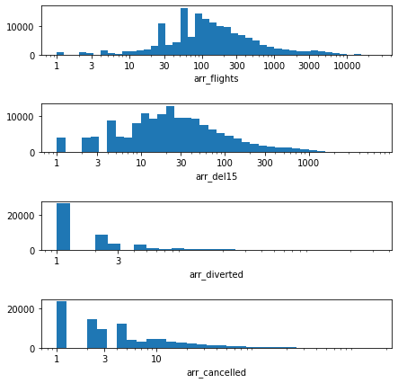

```python
number_of_flights = ['arr_flights','arr_del15','arr_diverted','arr_cancelled']
fig,ax = plt.subplots(nrows=4,figsize=(7,7),gridspec_kw={'hspace':1})
xlims = [30000,3000,10,30]
labels = [1,3,10,30,100,300,1000,3000,10000,30000]
for i,n in enumerate(number_of_flights):
    step = 0.1
    nbins = 10**np.arange(0,np.log10(flight_df[n].max())+step,step)
    ax[i].hist(data = flight_df,x=n,bins=nbins)
    ax[i].set_xlabel(n)
    ax[i].set_xscale('log')
    ind =labels.index(xlims[i])
    #print(ind)
    ax[i].set_xticks(labels[:ind])
    ax[i].set_xticklabels(labels[:ind])
```

> The distributions don't look to be changed after removing 2020

> now let's see how the human error related delation time as well as number of flights delation because of human contributions distributed.

```python
flight_df.columns
```

```
Index(['year', 'month', 'carrier', 'carrier_name', 'airport', 'airport_name',
       'arr_flights', 'arr_del15', 'carrier_ct', 'weather_ct', 'nas_ct',
       'security_ct', 'late_aircraft_ct', 'arr_cancelled', 'arr_diverted',
       'arr_delay', 'carrier_delay', 'weather_delay', 'nas_delay',
       'security_delay', 'late_aircraft_delay', 'flights_sum'],
      dtype='object')
```

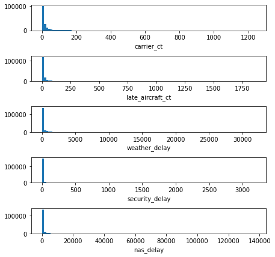

```python
delays = ['carrier_delay','late_aircraft_delay','weather_delay','security_delay','nas_delay']
cts = ['carrier_ct','late_aircraft_ct','weather_delay','security_delay','nas_delay']
flight_df['human_ct'] = flight_df[['carrier_ct','late_aircraft_ct']].sum(axis=1)
flight_df['human_delay'] = flight_df[['carrier_delay','late_aircraft_delay']].sum(axis=1)
fig,ax = plt.subplots(nrows=5,figsize=(7,7),gridspec_kw={'hspace':1})
for i,n in enumerate(cts):
    step = (flight_df[n].max() - flight_df[n].min())/100
    nbins = np.arange(0,flight_df[n].max()+step,step)
    ax[i].hist(data = flight_df,x=n,bins=nbins)
    ax[i].set_xlabel(n)
```

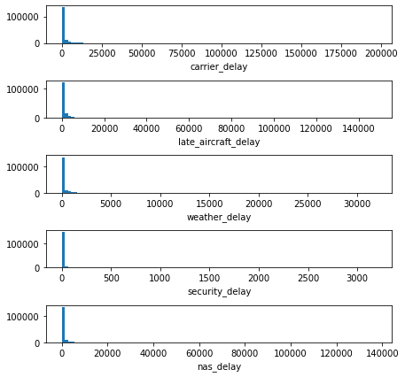

```python
fig,ax = plt.subplots(nrows=5,figsize=(7,7),gridspec_kw={'hspace':1})

for i,n in enumerate(delays):
    step = (flight_df[n].max() - flight_df[n].min())/100
    nbins = np.arange(0,flight_df[n].max()+step,step)
    ax[i].hist(data = flight_df,x=n,bins=nbins)
    ax[i].set_xlabel(n)
```

> use log scale

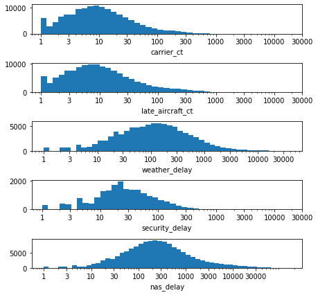

```python
fig,ax = plt.subplots(nrows=5,figsize=(7,7),gridspec_kw={'hspace':1})
#xlims = [30000,3000,10,30]
labels = [1,3,10,30,100,300,1000,3000,10000,30000]
for i,n in enumerate(cts):
    step = 0.1
    nbins = 10**np.arange(0,np.log10(flight_df[n].max())+step,step)
    ax[i].hist(data = flight_df,x=n,bins=nbins)
    ax[i].set_xlabel(n)
    ax[i].set_xscale('log')
    #ind =labels.index(xlims[i])
    #print(ind)
    ax[i].set_xticks(labels[:])
    ax[i].set_xticklabels(labels[:])
```

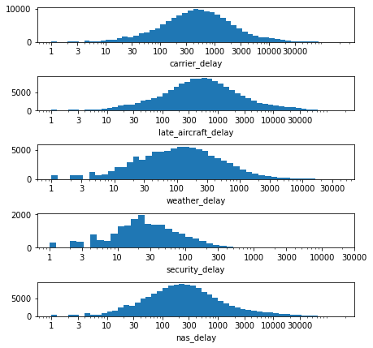

```python
fig,ax = plt.subplots(nrows=5,figsize=(7,7),gridspec_kw={'hspace':1})

for i,n in enumerate(delays):
    step = 0.1
    nbins = 10**np.arange(0,np.log10(flight_df[n].max())+step,step)
    ax[i].hist(data = flight_df,x=n,bins=nbins)
    ax[i].set_xlabel(n)
    ax[i].set_xscale('log')
    #ind =labels.index(xlims[i])
    #print(ind)
    ax[i].set_xticks(labels[:])
    ax[i].set_xticklabels(labels[:])
```

> surprisingly the two human delays and contributions related variables looks to follow each others in the distribution which suggests correlation between the carriers proplems and the late aircrafts proplems. Normal distribution in the delay caused by each cause and right skewed distribution in the number of flights delayed because of each cause.

> We can see also that nas delay and weather delays has the same distributions.

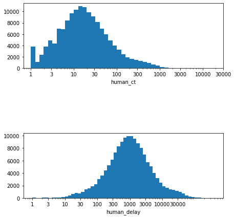

```python
human_sums = ['human_ct','human_delay']
fig,ax = plt.subplots(nrows=2,figsize=(7,7),gridspec_kw={'hspace':1})

for i,n in enumerate(human_sums):
    step = 0.1
    nbins = 10**np.arange(0,np.log10(flight_df[n].max())+step,step)
    ax[i].hist(data = flight_df,x=n,bins=nbins)
    ax[i].set_xlabel(n)
    ax[i].set_xscale('log')
    #ind =labels.index(xlims[i])
    #print(ind)
    ax[i].set_xticks(labels[:])
    ax[i].set_xticklabels(labels[:])
```

> The sum give us the same distribution for the contribution and the delay time caused by each human factor.

### Discuss the distribution(s) of your variable(s) of interest. Were there any unusual points? Did you need to perform any transformations?

> There were outliers in the number of flights arrived which caused outliers in the number of cancelled flights and high numbers in other columns. The year 2020 had unusual situations that made more unusual records due to Covid-19 pandemic and these records were removed. The log scale was necessary in the investigation as there were long tails in the histograms.

## Bivariate Exploration

> Start with pairplots for numerical features in interest.

```python
flight_df.columns
```

```
Index(['year', 'month', 'carrier', 'carrier_name', 'airport', 'airport_name',
       'arr_flights', 'arr_del15', 'carrier_ct', 'weather_ct', 'nas_ct',
       'security_ct', 'late_aircraft_ct', 'arr_cancelled', 'arr_diverted',
       'arr_delay', 'carrier_delay', 'weather_delay', 'nas_delay',
       'security_delay', 'late_aircraft_delay', 'flights_sum', 'human_ct',
       'human_delay'],
      dtype='object')
```

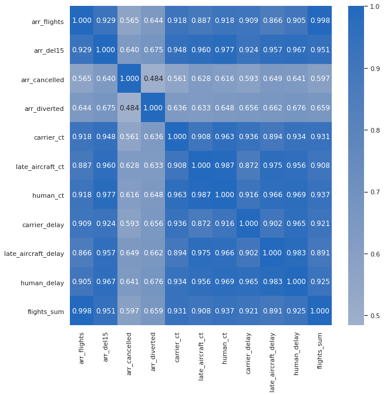

```python
sb.set(font_scale=1)

numer_feat = ['arr_flights', 'arr_del15',
              'arr_cancelled', 'arr_diverted','carrier_ct','late_aircraft_ct', 'human_ct','carrier_delay','late_aircraft_delay','human_delay','flights_sum']
corr_mat = flight_df[numer_feat].corr()
plt.figure(figsize=(10,10))
sb.heatmap(corr_mat,annot=True,fmt=".3f",cmap = 'vlag_r',center = 0)
```

> looks like the relations between the variables we are working with are very strong except for the cancelation and divertion.

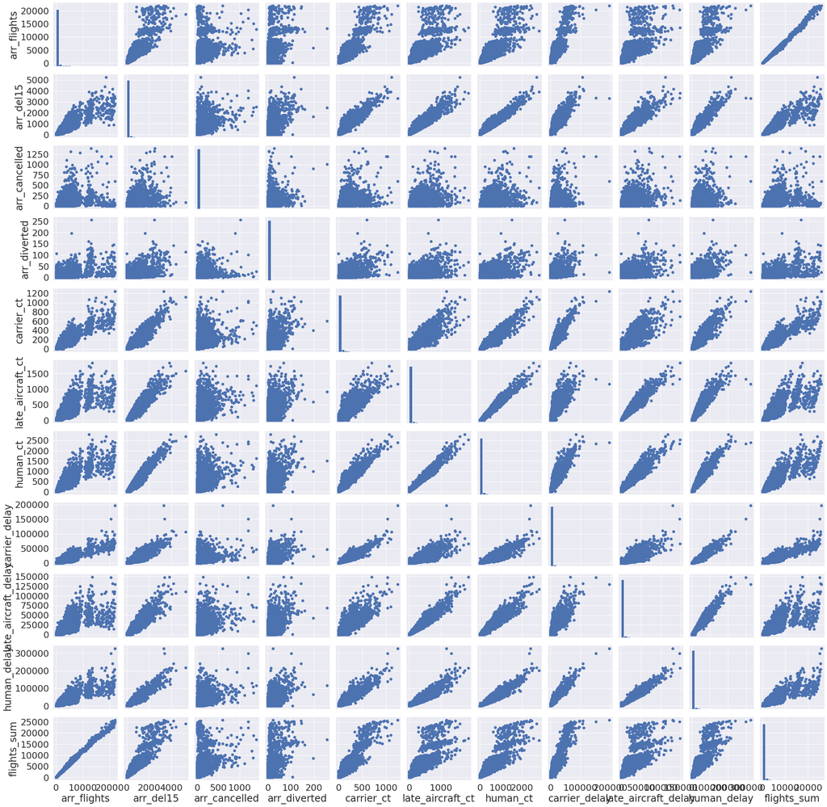

```python
#plt.figure(figsize=(15,15))
sb.set(font_scale=2)

sample = flight_df
g = sb.PairGrid(data=sample,vars=numer_feat)
g.map_diag(plt.hist,bins=20)
g.map_offdiag(plt.scatter)
sb.set(font_scale=1)
```

> looks like we got some interesting trends. The relations between the variables tend to be linear with high, intermediate or small slopes. Aggregating the humans delation and contribution looks to has perfect relation ships with the whole delation time and the whole number of flights delayed.

> The cancelation and divertion don't have a lot to do with the other data and looks to have relatively weak relationships with delations and number of arrived flights so, we will focus only on delation and its causes to evaluate the carriers and the airports performance.

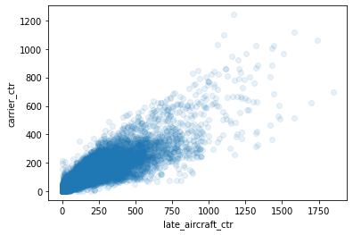

```python
plt.scatter(data=flight_df,x='late_aircraft_ct',y='carrier_ct',alpha=1/10)
plt.xlabel('late_aircraft_ctr')
plt.ylabel('carrier_ctr');
```

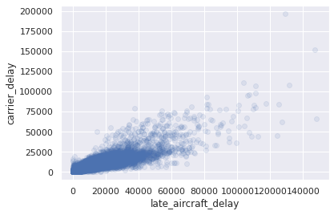

```python
plt.scatter(data=flight_df,x='late_aircraft_delay',y='carrier_delay',alpha=1/10)
plt.xlabel('late_aircraft_delay')
plt.ylabel('carrier_delay');
```

> Linear relationships exists between these two variables with low slobes which suggests that the carriers delays affects the aircrafts to be more late or the opposite.

> We will get two metrics for performance the first is the ratio between the human contribution in number of delayed flights to the whle delayed flights. The second one is the ratio between the minutes delayed by humans to the total delation.

> lets now construct two data frames to adress the carriers performance and the airports performance

```python
df_carriers = flight_df.groupby(by=['year','month','carrier']).sum().reset_index()
df_airports = flight_df.groupby(by=['year','month','airport']).sum().reset_index()
df_carriers.head()
```

|  | year | month | carrier | arr_flights | arr_del15 | carrier_ct | weather_ct | nas_ct | security_ct | late_aircraft_ct | ... | arr_diverted | arr_delay | carrier_delay | weather_delay | nas_delay | security_delay | late_aircraft_delay | flights_sum | human_ct | human_delay |
| --- | --- | --- | --- | --- | --- | --- | --- | --- | --- | --- | --- | --- | --- | --- | --- | --- | --- | --- | --- | --- | --- |
| 0 | 2010 | 1 | 9E | 21875.0 | 4921.0 | 1260.32 | 148.04 | 2314.13 | 9.18 | 1189.27 | ... | 91.0 | 254031.0 | 82459.0 | 14934.0 | 78405.0 | 374.0 | 77859.0 | 27785.0 | 2449.59 | 160318.0 |
| 1 | 2010 | 1 | AA | 46571.0 | 8143.0 | 2818.61 | 415.60 | 2778.63 | 21.91 | 2108.31 | ... | 130.0 | 421921.0 | 163830.0 | 24785.0 | 106993.0 | 2370.0 | 123943.0 | 56000.0 | 4926.92 | 287773.0 |
| 2 | 2010 | 1 | AS | 10532.0 | 1339.0 | 289.43 | 51.30 | 639.56 | 1.25 | 357.50 | ... | 68.0 | 63346.0 | 16954.0 | 3097.0 | 22672.0 | 32.0 | 20591.0 | 12032.0 | 646.93 | 37545.0 |
| 3 | 2010 | 1 | B6 | 16250.0 | 3867.0 | 1073.44 | 42.87 | 1341.03 | 8.45 | 1401.21 | ... | 28.0 | 257031.0 | 72624.0 | 3264.0 | 71570.0 | 378.0 | 109195.0 | 20387.0 | 2474.65 | 181819.0 |
| 4 | 2010 | 1 | CO | 19651.0 | 3339.0 | 891.04 | 97.53 | 1564.06 | 130.92 | 655.46 | ... | 28.0 | 169416.0 | 48836.0 | 5491.0 | 65730.0 | 8982.0 | 40377.0 | 23121.0 | 1546.50 | 89213.0 |

5 rows × 21 columns

```python
df_carriers['hu_del_per'] = df_carriers['human_delay']/df_carriers['arr_delay']
df_carriers['hu_ctr_per'] = df_carriers['human_ct']/df_carriers['arr_del15']

df_airports['hu_del_per'] = df_airports['human_delay']/df_airports['arr_delay']
df_airports['hu_ctr_per'] = df_airports['human_ct']/df_airports['arr_del15']
```

> I will start with the carriers

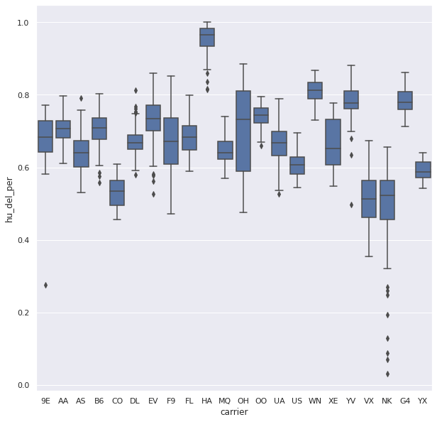

```python
plt.figure(figsize=(10,10))
color = sb.color_palette()[0]
sb.boxplot(data=df_carriers,x='carrier',y='hu_del_per',color=color)
```

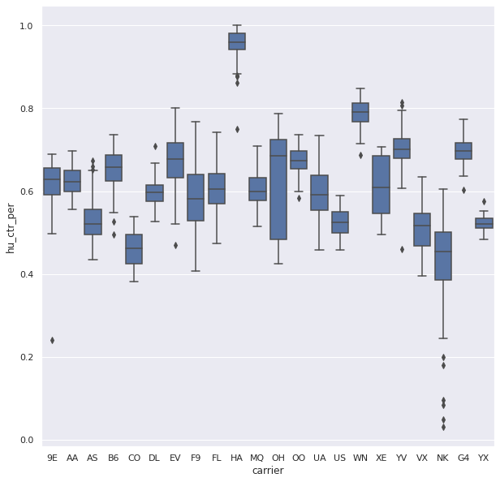

```python
plt.figure(figsize=(10,10))
color = sb.color_palette()[0]
sb.boxplot(data=df_carriers,x='carrier',y='hu_ctr_per',color=color)
```

> The two plots looks very similar. We have the HA carrier as the worst carrier with approximately 100% human contribution in delation. The NK carrier looks to be the best with 50% mean.

```python
def plot_log(x,**kwargs):
    labels = [1,3,10,30,100,300,1000,3000,10000,30000]

    step = 0.1
    nbins = 10**np.arange(0,np.log10(x.max())+step,step)
    plt.hist(x,bins=nbins)
    plt.xscale('log')

    plt.xticks(labels,labels)
```

```python
k = df_carriers.groupby('carrier').mean()
order = k['hu_del_per'].sort_values(ascending=False).index
```

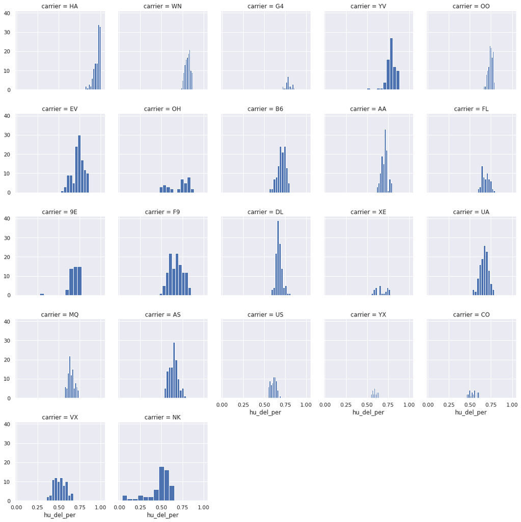

```python
g=sb.FacetGrid(df_carriers,col='carrier', col_wrap = 5, height = 3,col_order=order)
g.map(plt.hist,'hu_del_per')
```

> some carriers just look as they dont have a lot of records which will require to see how the time affected thier presence. We can see the smooth move of the distributions mean from right to left which indicates less human contribution to the time delay in the delayed flights.

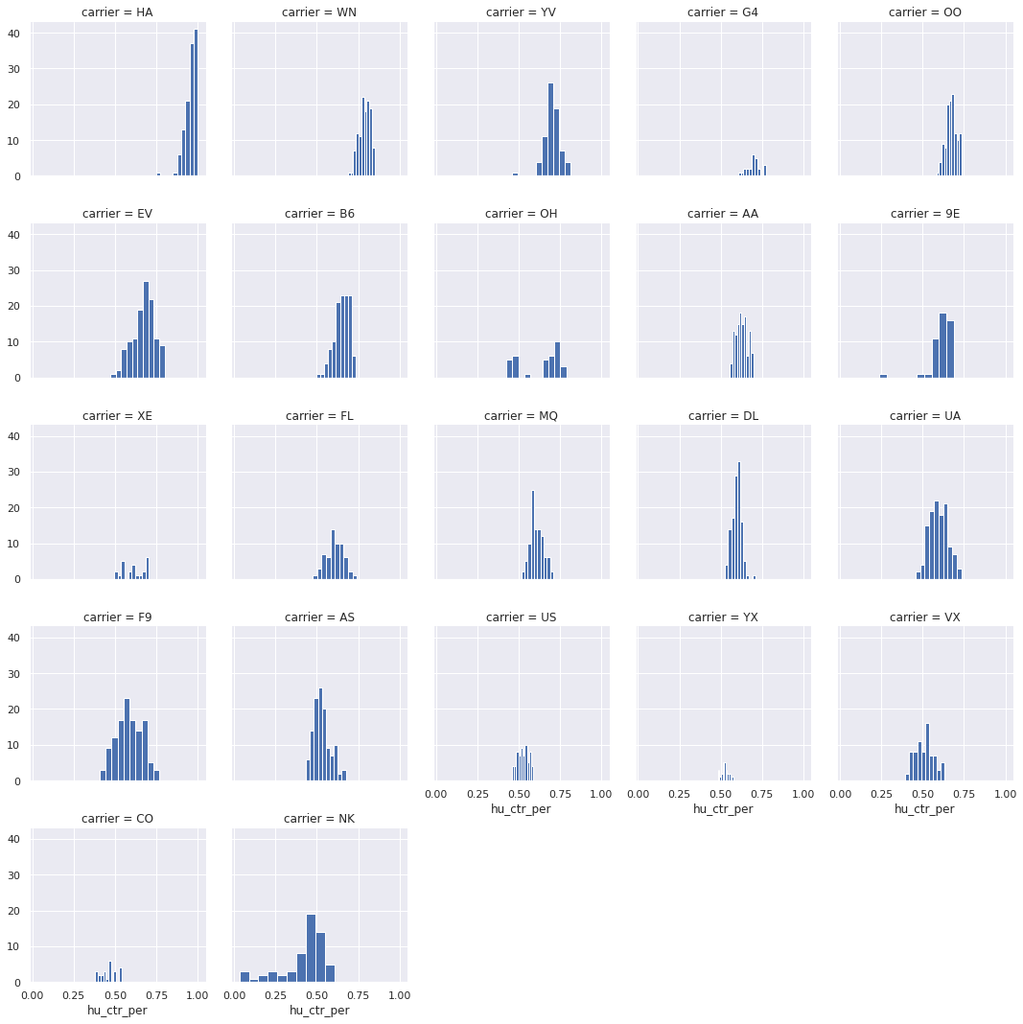

```python
k = df_carriers.groupby('carrier').mean()
order = k['hu_ctr_per'].sort_values(ascending=False).index

g=sb.FacetGrid(df_carriers,col='carrier', col_wrap = 5, height = 3,col_order=order)
g.map(plt.hist,'hu_ctr_per')
```

> The distributions of the flights delayed because of humans percentage looks to have almost the same info.

```python
df_carriers['day'] = 1
k = pd.to_datetime(df_carriers[['year','month','day']])
df_carriers['time_stamp'] = k
df_carriers['time_stamp'] = pd.to_datetime(df_carriers['time_stamp']).astype('str')
```

```python
df_carriers.head()
```

|  | year | month | carrier | arr_flights | arr_del15 | carrier_ct | weather_ct | nas_ct | security_ct | late_aircraft_ct | ... | arr_diverted | arr_delay | carrier_delay | weather_delay | nas_delay | security_delay | late_aircraft_delay | flights_sum | day | time_stamp |
| --- | --- | --- | --- | --- | --- | --- | --- | --- | --- | --- | --- | --- | --- | --- | --- | --- | --- | --- | --- | --- | --- |
| 0 | 2010 | 1 | 9E | 21875.0 | 4921.0 | 1260.32 | 148.04 | 2314.13 | 9.18 | 1189.27 | ... | 91.0 | 254031.0 | 82459.0 | 14934.0 | 78405.0 | 374.0 | 77859.0 | 27785.0 | 1 | 2010-01-01 |
| 1 | 2010 | 1 | AA | 46571.0 | 8143.0 | 2818.61 | 415.60 | 2778.63 | 21.91 | 2108.31 | ... | 130.0 | 421921.0 | 163830.0 | 24785.0 | 106993.0 | 2370.0 | 123943.0 | 56000.0 | 1 | 2010-01-01 |
| 2 | 2010 | 1 | AS | 10532.0 | 1339.0 | 289.43 | 51.30 | 639.56 | 1.25 | 357.50 | ... | 68.0 | 63346.0 | 16954.0 | 3097.0 | 22672.0 | 32.0 | 20591.0 | 12032.0 | 1 | 2010-01-01 |
| 3 | 2010 | 1 | B6 | 16250.0 | 3867.0 | 1073.44 | 42.87 | 1341.03 | 8.45 | 1401.21 | ... | 28.0 | 257031.0 | 72624.0 | 3264.0 | 71570.0 | 378.0 | 109195.0 | 20387.0 | 1 | 2010-01-01 |
| 4 | 2010 | 1 | CO | 19651.0 | 3339.0 | 891.04 | 97.53 | 1564.06 | 130.92 | 655.46 | ... | 28.0 | 169416.0 | 48836.0 | 5491.0 | 65730.0 | 8982.0 | 40377.0 | 23121.0 | 1 | 2010-01-01 |

5 rows × 21 columns

```python
ct_counts = df_carriers.groupby(['time_stamp', 'carrier']).size()
ct_counts = ct_counts.reset_index()
ct_counts2 = ct_counts.pivot(index = 'time_stamp', columns = 'carrier')
k = ct_counts2.sum().sort_values(ascending=False).index
order = [el[1]for el in k]
```

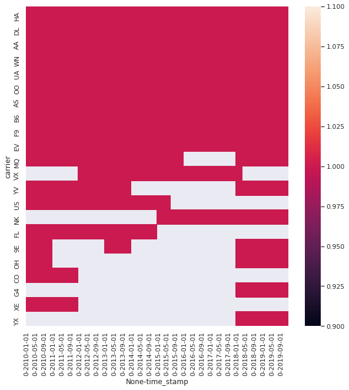

```python
plt.figure(figsize=(10,10))
ct_counts = df_carriers.groupby(['time_stamp', 'carrier']).size()
ct_counts = ct_counts.reset_index()
ct_counts = ct_counts.pivot(index = 'carrier', columns = 'time_stamp')
ct_counts = ct_counts.reindex(order)

sb.heatmap(ct_counts)
```

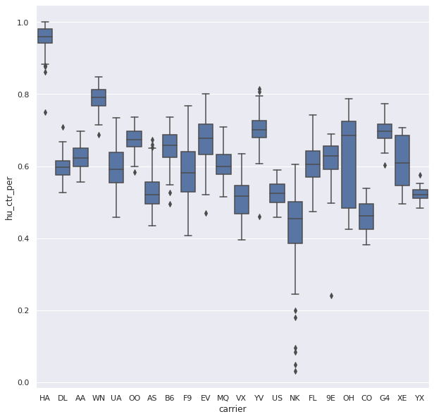

```python
plt.figure(figsize=(10,10))
color = sb.color_palette()[0]
sb.boxplot(data=df_carriers,x='carrier',y='hu_ctr_per',color=color,order = order)
```

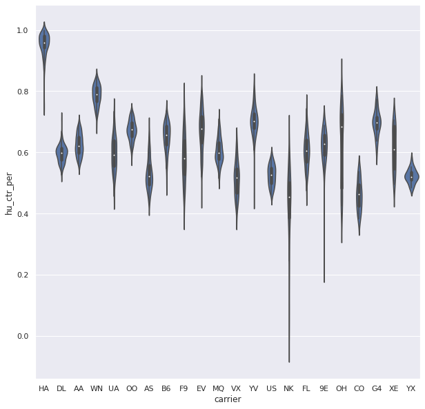

```python
plt.figure(figsize=(10,10))
color = sb.color_palette()[0]
sb.violinplot(data=df_carriers,x='carrier',y='hu_ctr_per',color=color,order = order)
```

> The heat map gives some important information. Some of the carriers were present in the whole 10 years. Other carriers had break in the middle years. These carriers have smaller number of records. Other carriers worked only in the final 2 years or the first 2 years.

> We can conclude that HA is the worst carrier. The best carrier is NK with human delay contribution slightly higher than 40% . AS has low mean (near to NK) but has a small human delay contribution despite the long time the data is recorded about it.

## Airports with the carriers

```python
#k = df_carriers.groupby('carrier').mean()
#order = k['hu_ctr_per'].sort_values(ascending=False).index
ct_counts = df_carriers.groupby(['time_stamp', 'carrier']).size()
ct_counts = ct_counts.reset_index()
ct_counts2 = ct_counts.pivot(index = 'time_stamp', columns = 'carrier')
k = ct_counts2.sum().sort_values(ascending=False).index
order = [el[1]for el in k]
```

```
<BarContainer object of 22 artists>
```

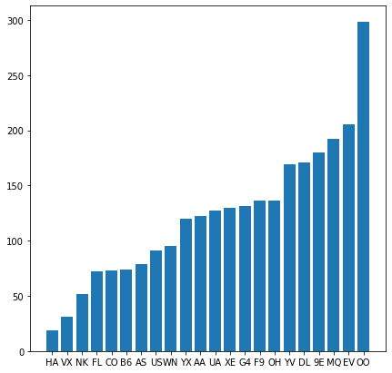

```python
plt.figure(figsize=(7,7))
ct_counts = flight_df.groupby(['airport', 'carrier']).size()
ct_counts = ct_counts.reset_index()
ct_counts = ct_counts.pivot(index = 'carrier', columns = 'airport')
ct_counts = ct_counts.reindex(order)
y = []
for el in order:
    k = ct_counts.loc[el]
    y.append(len(k[~ k.isna()]))

order = pd.Series(y,order).sort_values().index
y=[]
for el in order:
    k = ct_counts.loc[el]
    y.append(len(k[~ k.isna()]))
plt.bar(order,y)
```

> The relationship between the number of airports a carrier is dealing with and the effecienc of a carrier is not obvious. We can notice that the worst carrier deals with the smallest number of airports. We can see too AS and NK deal with small number of airports. Some carriers which were working for the whole 10 years.

```python
k1 = ct_counts.loc['US'].dropna().index
k2 = ct_counts.loc['HA'].dropna().index
k3 = ct_counts.loc['NK'].dropna().index
print(len(k2)-len(np.setdiff1d(k2,k1)))
print(len(k3)-len(np.setdiff1d(k3,k1)))
print(len(k3)-len(np.setdiff1d(k3,k2)))
```

```
0
0
0
```

> This means that the airports the three carriers are working in are completely different

```python
for car in ['US','NK','HA']:
    print(flight_df.query('carrier == @car').carrier_name.unique())
```

```
['US Airways Inc.']
['Spirit Air Lines']
['Hawaiian Airlines Inc.']
```

### Did you observe any interesting relationships between the other features (not the main feature(s) of interest)?

> There are some carriers which closed after number of working years and others have discontinous time periods of working.

## Multivariate Exploration

> First let's see the number of flights for the carriers across the time

```python
ct_counts = df_carriers.groupby(['time_stamp', 'carrier']).size()
ct_counts = ct_counts.reset_index()
ct_counts2 = ct_counts.pivot(index = 'time_stamp', columns = 'carrier')
ct_counts2
```

| carrier time_stamp | 0 9E | 0 AA | 0 AS | 0 B6 | 0 CO | 0 DL | 0 EV | 0 F9 | 0 FL | 0 G4 | 0 ... | 0 NK | 0 OH | 0 OO | 0 UA | 0 US | 0 VX | 0 WN | 0 XE | 0 YV | 0 YX |
| --- | --- | --- | --- | --- | --- | --- | --- | --- | --- | --- | --- | --- | --- | --- | --- | --- | --- | --- | --- | --- | --- |
| 2010-01-01 | 1.0 | 1.0 | 1.0 | 1.0 | 1.0 | 1.0 | 1.0 | 1.0 | 1.0 | NaN | ... | NaN | 1.0 | 1.0 | 1.0 | 1.0 | NaN | 1.0 | 1.0 | 1.0 | NaN |
| 2010-02-01 | 1.0 | 1.0 | 1.0 | 1.0 | 1.0 | 1.0 | 1.0 | 1.0 | 1.0 | NaN | ... | NaN | 1.0 | 1.0 | 1.0 | 1.0 | NaN | 1.0 | 1.0 | 1.0 | NaN |
| 2010-03-01 | 1.0 | 1.0 | 1.0 | 1.0 | 1.0 | 1.0 | 1.0 | 1.0 | 1.0 | NaN | ... | NaN | 1.0 | 1.0 | 1.0 | 1.0 | NaN | 1.0 | 1.0 | 1.0 | NaN |
| 2010-04-01 | 1.0 | 1.0 | 1.0 | 1.0 | 1.0 | 1.0 | 1.0 | 1.0 | 1.0 | NaN | ... | NaN | 1.0 | 1.0 | 1.0 | 1.0 | NaN | 1.0 | 1.0 | 1.0 | NaN |
| 2010-05-01 | 1.0 | 1.0 | 1.0 | 1.0 | 1.0 | 1.0 | 1.0 | 1.0 | 1.0 | NaN | ... | NaN | 1.0 | 1.0 | 1.0 | 1.0 | NaN | 1.0 | 1.0 | 1.0 | NaN |
| ... | ... | ... | ... | ... | ... | ... | ... | ... | ... | ... | ... | ... | ... | ... | ... | ... | ... | ... | ... | ... | ... |
| 2019-08-01 | 1.0 | 1.0 | 1.0 | 1.0 | NaN | 1.0 | 1.0 | 1.0 | NaN | 1.0 | ... | 1.0 | 1.0 | 1.0 | 1.0 | NaN | NaN | 1.0 | NaN | 1.0 | 1.0 |
| 2019-09-01 | 1.0 | 1.0 | 1.0 | 1.0 | NaN | 1.0 | 1.0 | 1.0 | NaN | 1.0 | ... | 1.0 | 1.0 | 1.0 | 1.0 | NaN | NaN | 1.0 | NaN | 1.0 | 1.0 |
| 2019-10-01 | 1.0 | 1.0 | 1.0 | 1.0 | NaN | 1.0 | 1.0 | 1.0 | NaN | 1.0 | ... | 1.0 | 1.0 | 1.0 | 1.0 | NaN | NaN | 1.0 | NaN | 1.0 | 1.0 |
| 2019-11-01 | 1.0 | 1.0 | 1.0 | 1.0 | NaN | 1.0 | 1.0 | 1.0 | NaN | 1.0 | ... | 1.0 | 1.0 | 1.0 | 1.0 | NaN | NaN | 1.0 | NaN | 1.0 | 1.0 |
| 2019-12-01 | 1.0 | 1.0 | 1.0 | 1.0 | NaN | 1.0 | 1.0 | 1.0 | NaN | 1.0 | ... | 1.0 | 1.0 | 1.0 | 1.0 | NaN | NaN | 1.0 | NaN | 1.0 | 1.0 |

120 rows × 22 columns

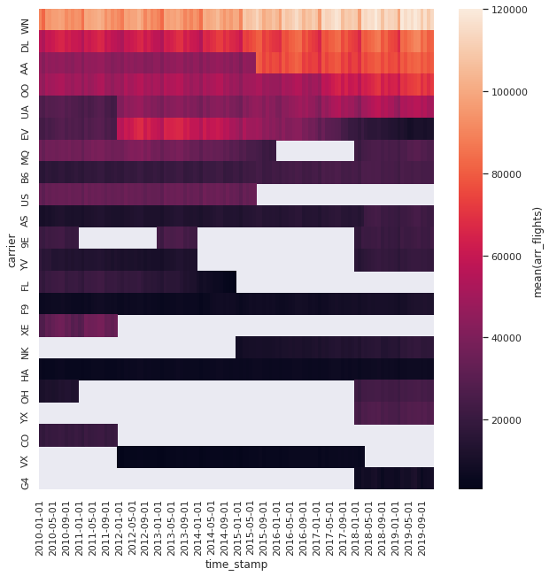

```python
plt.figure(figsize=(10,10))
cat_means = df_carriers.groupby(['time_stamp', 'carrier']).mean()['arr_flights']
cat_means = cat_means.reset_index(name = 'arr_flights_avg')
cat_means = cat_means.pivot(index = 'carrier', columns = 'time_stamp',
                             values = 'arr_flights_avg')

order = cat_means.sum(axis=1).sort_values(ascending=False).index
cat_means = cat_means.reindex(order)
sb.heatmap(cat_means,
           cbar_kws = {'label' : 'mean(arr_flights)'})
```

> This figure explains a lot!. The three previous carriers were actually low in the number of flights. Actually the first 5 carriers holds most of the flights

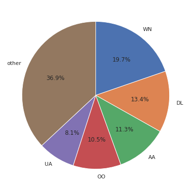

```python
cars = ['WN','DL','AA','OO','UA']


plt.figure(figsize=(7,7))
order = cat_means.sum(axis=1).sort_values(ascending=False)
order['other'] = order[~order.index.isin(cars)].sum()
order = order[(order.index.isin(cars)) | (order.index=='other')]



plt.pie(order,labels = order.index, startangle= 90
,counterclock = False, autopct='%1.1f%%');
```

> let's see the human delation with time for the first 5 carriers with years

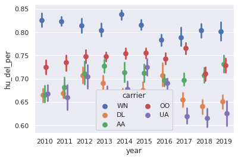

```python
cars = ['WN','DL','AA','OO','UA']
sample = df_carriers.query('carrier in @cars')
ax = sb.pointplot(data = sample, x = 'year', y = 'hu_del_per', hue = 'carrier',
                  dodge = 0.3, linestyles = "",hue_order=cars)
ax.legend(loc = 8, ncol = 2, framealpha = 1, title = 'carrier')
```

> WN has significant human delation which looks to be corresponding to the high arrived flights it has. UA has the least human delation as it has the lower flights number. Surprisingly, DL is the second best one in human delation and it is the second highest componey in flights.

> Following AA which is the third in airflights percent and has the third lowest human delation. OO is the forth in number of flights but the second in the human delation. OO looks to be improving in the last two years to match AA(percentage of flights in both OO and AA is almost the sam). It also has increasing flights rate at the last four years. OO is also deals with the largest number of airports.

> We can also notice the general high human delation (60% or above) which looks to be acceptable range for this range of flights number (which is also the reason we didn't notice these carriers before).

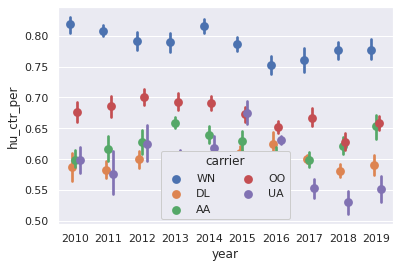

```python
cars = ['WN','DL','AA','OO','UA']
sample = df_carriers.query('carrier in @cars')
ax = sb.pointplot(data = sample, x = 'year', y = 'hu_ctr_per', hue = 'carrier',
                  dodge = 0.3, linestyles = "",hue_order=cars)
ax.legend(loc = 8, ncol = 2, framealpha = 1, title = 'carrier')
```

> The human contribution in the number of flights delayed gives similar info too.

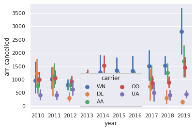

```python
cars = ['WN','DL','AA','OO','UA']
sample = df_carriers.query('carrier in @cars')
ax = sb.pointplot(data = sample, x = 'year', y = 'arr_cancelled', hue = 'carrier',
                  dodge = 0.3, linestyles = "",hue_order=cars)
ax.legend(loc = 8, ncol = 2, framealpha = 1, title = 'carrier')
```

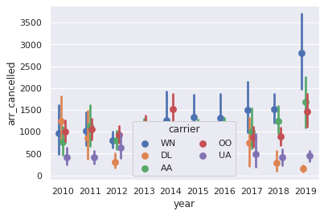

```python
cars = ['WN','DL','AA','OO','UA']
sample = df_carriers.query('carrier in @cars')
ax = sb.pointplot(data = sample, x = 'year', y = 'arr_cancelled', hue = 'carrier',
                  dodge = 0.3, linestyles = "",hue_order=cars)
ax.legend(loc = 8, ncol = 2, framealpha = 1, title = 'carrier')
```

> As the none zero values in cancellation and divertion are few we can't rely on the data to get a real conclusion

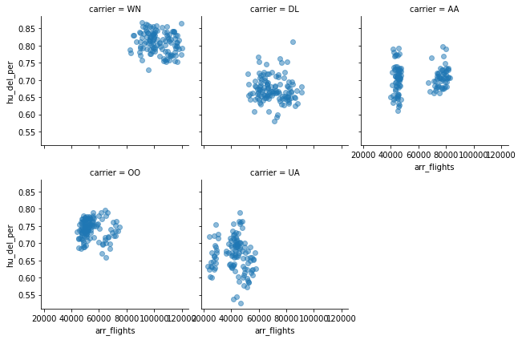

```python
cars = ['WN','DL','AA','OO','UA']
sample = df_carriers.query('carrier in @cars')
sample
g=sb.FacetGrid(data=sample,col = 'carrier', col_wrap = 3, size = 3,col_order=cars)
g.map(plt.scatter,'arr_flights','hu_del_per',alpha=5/10)
```

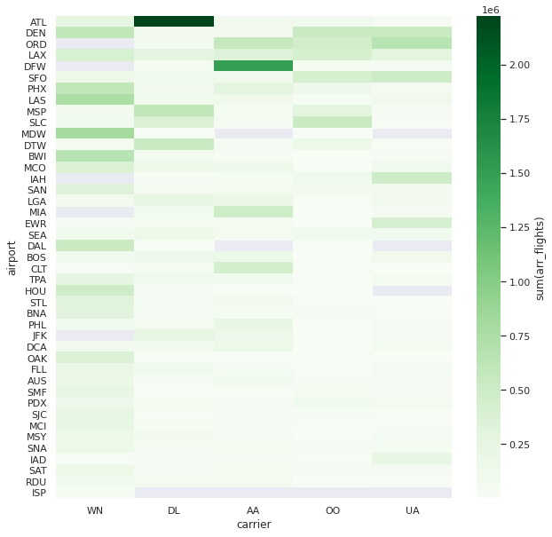

```python
sample = flight_df.query('carrier in @cars')
sample = flight_df.query('carrier in @cars')
cat_means = sample.groupby(['carrier', 'airport']).sum()['arr_flights']
cat_means = cat_means.reset_index(name = 'arr_flights_avg')
cat_means = cat_means.pivot(index = 'airport', columns = 'carrier',
                            values = 'arr_flights_avg')
k = cat_means.mean(axis=1)
k=k[k>50000]
cat_means = cat_means.loc[k.index]
#cat_means = cat_means.reindex(cars)
cat_means = cat_means[cars]
order = cat_means.sum(axis=1).sort_values(ascending=False).index
cat_means = cat_means.reindex( order)
plt.figure(figsize=(10,10))
sb.heatmap(cat_means, fmt = '.3f',
           cbar_kws = {'label' : 'sum(arr_flights)'},cmap="Greens")
#cat_means
```

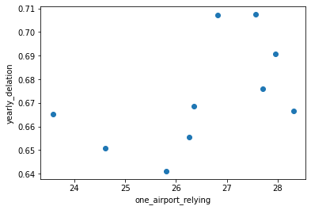

```python
sample = flight_df.query('carrier == "DL"')
one_airport_relying = sample.groupby(['year','airport']).agg({'arr_flights': 'sum'}).groupby(level=0).apply(lambda x:
                                                 100 * x / float(x.sum())).reset_index(0).groupby('year').max()
sample = df_carriers.query('carrier == "DL"')
yearly_delation = sample.groupby(['year']).agg({'hu_del_per': 'mean'})


plt.scatter(one_airport_relying,yearly_delation)
plt.xlabel('one_airport_relying')
plt.ylabel('yearly_delation')
```

```python
one_airport_relying
```

| year | arr_flights |
| --- | --- |
| 2010 | 23.574843 |
| 2011 | 26.347512 |
| 2012 | 27.563185 |
| 2013 | 27.947580 |
| 2014 | 28.311729 |
| 2015 | 27.703535 |
| 2016 | 26.815722 |
| 2017 | 26.252869 |
| 2018 | 25.809690 |
| 2019 | 24.605715 |

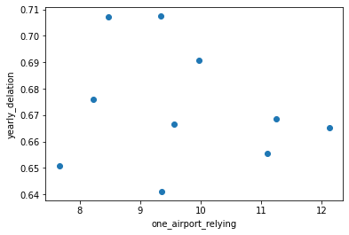

```python
sample = flight_df.query('carrier == "OO"')
one_airport_relying = sample.groupby(['year','airport']).agg({'arr_flights': 'sum'}).groupby(level=0).apply(lambda x:
                                                 100 * x / float(x.sum())).reset_index(0).groupby('year').max()
sample = df_carriers.query('carrier == "DL"')
yearly_delation = sample.groupby(['year']).agg({'hu_del_per': 'mean'})


plt.scatter(one_airport_relying,yearly_delation)
plt.xlabel('one_airport_relying')
plt.ylabel('yearly_delation')
```

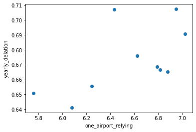

```python
sample = flight_df.query('carrier == "WN"')
one_airport_relying = sample.groupby(['year','airport']).agg({'arr_flights': 'sum'}).groupby(level=0).apply(lambda x:
                                                 100 * x / float(x.sum())).reset_index(0).groupby('year').max()
sample = df_carriers.query('carrier == "DL"')
yearly_delation = sample.groupby(['year']).agg({'hu_del_per': 'mean'})


plt.scatter(one_airport_relying,yearly_delation)
plt.xlabel('one_airport_relying')
plt.ylabel('yearly_delation')
```

> let's see the relation between relying on one airport and human error

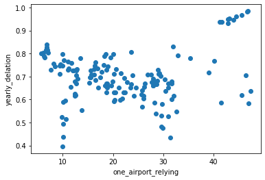

```python
sample = df_carriers.groupby(['year','carrier']).agg({'arr_flights':'sum','hu_del_per':'mean'})
one_airport_relying = flight_df.groupby(['carrier','year','airport']).agg({'arr_flights': 'sum'}).groupby(level=[0,1]).apply(lambda x:
                                                 100 * x / float(x.sum())).groupby(level=[0,1]).max()
yearly_delation = df_carriers.groupby(['carrier','year']).agg({'hu_del_per': 'mean'})
#yearly_delation
plt.scatter(one_airport_relying,yearly_delation)
#one_airport_relying
plt.xlabel('one_airport_relying')
plt.ylabel('yearly_delation')
```

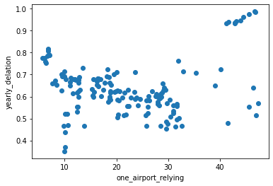

```python
sample = df_carriers.groupby(['year','carrier']).agg({'arr_flights':'sum','hu_del_per':'mean'})
one_airport_relying = flight_df.groupby(['carrier','year','airport']).agg({'arr_flights': 'sum'}).groupby(level=[0,1]).apply(lambda x:
                                                 100 * x / float(x.sum())).groupby(level=[0,1]).max()
yearly_delation = df_carriers.groupby(['carrier','year']).agg({'hu_ctr_per': 'mean'})
#yearly_delation
plt.scatter(one_airport_relying,yearly_delation)
#one_airport_relying
plt.xlabel('one_airport_relying')
plt.ylabel('yearly_delation')
```

> The effect is even more obvious when checking with the contribution of humans in the number of the flights delayed.

```python
k = yearly_delation.reset_index(1)['hu_del_per']
k[k>0.9].index.unique()
```

```
Index(['HA'], dtype='object', name='carrier')
```

> The relation between how much a carrier is relying on one airport and the human delation looks to be negative

> The Hawaiian airlines has exceptional condition as they are relying on a small number of airoports but have high human delation.

```python
sample = df_carriers.groupby(['year','carrier']).agg({'arr_flights':'sum','hu_del_per':'mean'})
one_airport_relying = flight_df.groupby(['carrier','year','airport']).agg({'arr_flights': 'sum'}).groupby(level=[0,1]).apply(lambda x:
                                                 100 * x / float(x.sum())).groupby(level=[0,1]).max()
yearly_delation = df_carriers.groupby(['carrier','year']).agg({'hu_del_per': 'mean'})
#yearly_delation
plt.scatter(one_airport_relying,yearly_delation)
#one_airport_relying
```

```python
cars = ['WN','DL','AA','OO','UA']

for car in cars:
    print(flight_df.query('carrier == @car').carrier_name.unique())
```

```
['Southwest Airlines Co.']
['Delta Air Lines Inc.']
['American Airlines Inc.']
['SkyWest Airlines Inc.']
['United Air Lines Inc.']
```

### Were there any interesting or surprising interactions between features?

> The biggest carrier doesn't have a main airport but alternatively it has relative above moderate number of flights in a lot of airports. However the second bigger carrier which has a very low human delation contribution is relying on one airport heavily. The relation between the dependency on one airport and human delation looks to be negative.